# NAFCAnalysis

testing

`r`r library(dplyr)

`r`r library(ggplot2) library(ggthemes) library(gridExtra)

`r`r library(lme4)

`r`r NAFCdata<-read.csv(/Users/jreyn/OneDrive/Documents/grad school/NAFHM19/Data/Rfiles/NAFCsummaryR.csv) NAFCdata$FNominal.NAFC<- as.factor(NAFCdata$FNominal.NAFC) NAFCdata$FDay.of.experiment<- as.factor(NAFCdata$FDay.of.experiment) NAFCdata

| IDay.of.experiment | FNominal.NAFC | Measured.NAFC | INominal.NAFC | FDay.of.experiment |
| --- | --- | --- | --- | --- |
| 0 | 0 mg/L | 0.48 | 0.0 | Day 0 |
| 0 | 2.5 mg/L | 1.47 | 2.5 | Day 0 |
| 0 | 6.5 mg/L | 3.16 | 6.5 | Day 0 |
| 0 | 10 mg/L | 4.48 | 10.0 | Day 0 |
| 0 | 14 mg/L | 5.97 | 14.0 | Day 0 |
| 0 | 21 mg/L | 9.20 | 21.0 | Day 0 |
| 0 | 29.5 mg/L | 11.53 | 29.5 | Day 0 |
| 0 | 40 mg/L | 13.08 | 40.0 | Day 0 |
| 0 | 54 mg/L | 20.16 | 54.0 | Day 0 |
| 2 | 0 mg/L | 0.50 | 0.0 | Day 2 |

[output cut: 16 more lines]

`r`r NAFCdata$FNominal.NAFC <- factor(NAFCdata$FNominal.NAFC, levels = c(\0 mg/L, \2.5 mg/L, \6.5 mg/L, \10 mg/L, \14 mg/L, \21 mg/L, \29.5 mg/L, \40 mg/L, \54 mg/L)) a<- ggplot(NAFCdata, aes(x=IDay.of.experiment, y= Measured.NAFC, group= FNominal.NAFC ))+ geom_point(aes(shape=FNominal.NAFC))+ geom_line()+ scale_shape_manual(values=c(3, 16, 17, 15, 13, 8, 10, 2, 7))+ geom_vline(linetype=, xintercept = 0)+ geom_vline(linetype=, xintercept = 3)+ ylab(‘Measured NAFC concentration (mg/L)’)+ xlab(‘Day of experiment’)+ theme_few()+ theme(legend.title = element_blank()) a

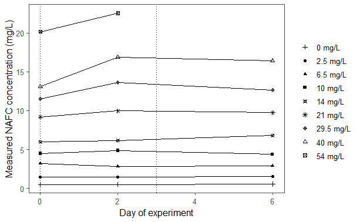

`r`r b<- ggplot(NAFCdata, aes(x=INominal.NAFC, y= Measured.NAFC, group=FDay.of.experiment ))+ geom_point(aes(colour=FDay.of.experiment, fill= FDay.of.experiment), shape= 21, size= 3, colour= )+ geom_abline(linetype=, intercept = 0, slope = 1)+ ylab(‘Measured NAFC concentration (mg/L)’)+ xlab(‘Nominal NAFC concentration (mg/L)’)+ scale_y_continuous(limits=c(0, 60))+ scale_x_continuous(limits=c(0, 60))+ theme_few()+ theme(legend.title = element_blank()) b

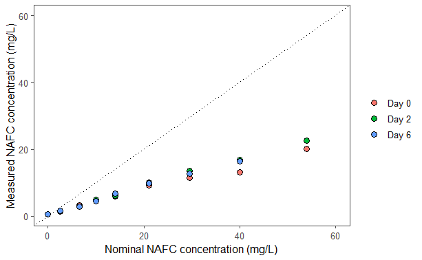